# As1

2022-10-18

Step 1: Run the following code Run the following code to load some clustering data with 2 features into your session.

```r
library(tidyverse)
library(RCurl)
x <- getURL("https://raw.githubusercontent.com/vankesteren/dav_practicals/master/12_Unsupervised_learning_Clustering/data/clusterdata.csv")
clus_df <- read.csv(text = x)
clus_df
```

```
##           x1       x2
## 1   5.899048 6.132604
## 2   5.023846 6.971529
## 3   7.068774 8.190088
## 4   5.117789 2.397339
## 5   4.221205 2.891753
## 6   6.275499 4.164369
## 7   6.915762 6.710639
## 8   3.425586 8.082163
## 9   4.971889 1.729247
## 10  7.055090 6.224843
## 11  2.412145 6.013079
## 12  5.320305 5.530396
## 13  2.459710 4.709007
## 14  5.848936 3.864982
```

[output cut: 86 more lines]

Step 2

The Euclidean distance between two vectors 𝐱 and 𝐲 of equal length 𝑁 is 𝐷 = ||𝐱 − 𝐲||2 = √∑𝑁 ( 𝑥 − 𝑦 )2. These two vectors represent points in 𝑁-dimensional space and the

Euclidian distance is the straight-line distance between these points. Write a function l2_dist(x, y) that takes in two vectors and outputs the Euclidian distance between the two vectors.

```r
#Euclidean distance function
l2_dist = function(x,y){
  return(sqrt(sum((x-y)^2)))}
```

Step 3: K-medians clustering algorithm K-medians is partitional clustering method. It is a variant of k-means where it calculates the median instead of calculating the mean for each cluster to determine its centroid. Program a K-medians clustering algorithm called kmedians. The inputs of this function should be X, a data frame, and K, an integer stating how many clusters you want. The output is (at least) the cluster assignments (an integer vector). Use your l2_dist function to compute the euclidian distance. Create helpful comments in the code along the way.

```r
#Set seed for reproducible results
set.seed(1)
#Definining function
kmed_clustering = function(x,k){

  #Assigning random groups to each data
  x$clusters <- sample(k, size=nrow(x), replace = TRUE)


  repeat { #infinite cicle
    changes <- TRUE # to scape from cycle

    #Obtaining centroids by medians method of each cluster
    by_clus <- x %>%
      group_by(clusters)  %>%
      summarise(
        centroidx = median(x1),
        centroidy = median(x2))

    #Defining empty matrix to store distances from each point to each cluster
    distances= matrix(,nrow=nrow(x),ncol=k)

    #Defining empty matrix to store the selected cluster
    winner = matrix(,nrow=nrow(x),ncol=1)

    #Double cycle to get distance for each row to each  cluster
    for (i in 1:nrow(x) ) {
      for (clus in 1:k) {
        distances[i,clus] = l2_dist(as.numeric(by_clus[clus,2:3]), as.numeric(x[i,1:2]))
      }

      #Get the best (minimum distance to a cluster)
      winner[i,1] = which (distances[i,1:k] == min(distances[i,1:k]), arr.ind = TRUE)
    }


    #To escape from cycle when there are not changes between clusters in  2 consecutive iterations
    if (identical(as.vector(x$clusters), c(t(winner)))) {
      changes <- FALSE
    }


    #Updating clusters
    x$clusters <- winner

    #If  there  are no more changes, break the cycle
    if (!changes) {break}
  }

  #Returning the optimum clusters vector
  return(winner)
}


#Running function to obtain k medians
kmedians_clusters= kmed_clustering(clus_df,4)


#creating df to store kmedian clusters
df_cluster_med <- clus_df
df_cluster_med$kmedian <- kmedians_clusters
df_cluster_med
```

```
##           x1       x2 kmedian
## 1   5.899048 6.132604       4
## 2   5.023846 6.971529       3
## 3   7.068774 8.190088       4
## 4   5.117789 2.397339       1
## 5   4.221205 2.891753       1
## 6   6.275499 4.164369       1
## 7   6.915762 6.710639       4
## 8   3.425586 8.082163       3
## 9   4.971889 1.729247       1
## 10  7.055090 6.224843       4
## 11  2.412145 6.013079       2
## 12  5.320305 5.530396       3
## 13  2.459710 4.709007       2
## 14  5.848936 3.864982       1
```

[output cut: 86 more lines]

Step 4: Compare to K-means Apply your kmedians function and the R kmeans function on clus_df and compare the results in a good visualisation. Reflect on the differences and similarities that you see.

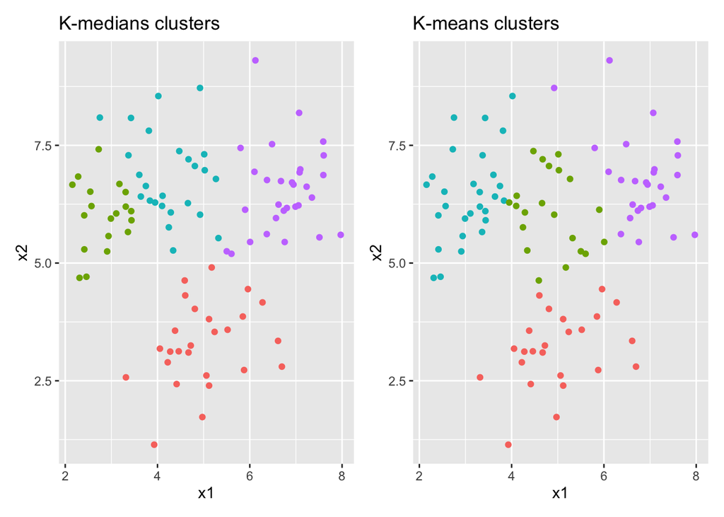

```r
#Computing kmean cluster with r function and storing to a df
df_cluster_mean <- clus_df
df = dist(df_cluster_mean)
df_cluster_mean$kmean = kmeans(df,4)$cluster


library(patchwork)
#plotting kmedians
p1 <- ggplot(df_cluster_med) + geom_point(aes(x1, x2, color = as.factor(kmedian)))  + ggtitle("K-medians clusters")

#plotting kmeans
p2 <- ggplot(df_cluster_mean) + geom_point(aes(x1, x2, color = as.factor(kmean))) + ggtitle("K-means clusters")


#Joining all and plotting
p1+theme(legend.position="none")+ p2+theme(legend.position="none")
```